# Data Assignment Final Report

Submitted by: **Eve Yuwei Qian**

## Introduction

This report aims to deliver some interesting facts and meaningful relationships among data values by exploring and analyzing patient data, pupil measurement, treatment and outcome, etc. There are various layers and facets involved in this subject, and this report only depicts a few of them and visualize them to make the data more understandable.

## Table of Content

- Data Process - Patient's Initial NPI
- Patient Data
- Pupil Data
- Diagnosis & Treatment
- Surgery Data Analysis
- Data Process - Ending NPi
- NPi Changes

## Data Process - Patient's Initial NPI

This section undergoes data processing to retrieve initial NPi value and pick out valid data points. It explores stories behind the basic information provided by different types of entries.

```python
# Import libraries
import matplotlib.pyplot as pyplot
import pandas as pd
import numpy as np
import sys
import math
from pandas import DataFrame
from sklearn import preprocessing
from sklearn.linear_model import LogisticRegression
from sklearn.model_selection import train_test_split
from numpy import loadtxt, where
from pylab import scatter, show, legend, xlabel, ylabel
import warnings; warnings.simplefilter('ignore')

# Read csv file
data = pd.read_csv("data.csv")
# Create initial data frame with columns from csv file
df = pd.DataFrame(columns=list(data.columns.values))
firstID = True
lastRowID = None

for index, row in data.iterrows():
    rowID = row['Study_ID']
    if firstID:
        # Add the first row to the data frame
        df.loc[len(df)] = row
        lastRowID = rowID
        firstID = False
    else:
        # Only add the row when the ID is different and NPI is valid
        if rowID != lastRowID and row['NPiL']>0:
            df.loc[len(df)] = row
            lastRowID = rowID
```

```python
# Print out first 5 lines of constructed data frame
df.head()
```

|  | Study_ID | NPiL | SizeL | MinL | PercChangeL | CVL | MCVL | DVL | LatL | NPiR | ... | Gender | Age | Death.at.Discharge | Diagnosis | Pathology.Side | IVH | EVD | Hyperosmolar.Therapy | Brain.Surgery | Surgery.Type |
| --- | --- | --- | --- | --- | --- | --- | --- | --- | --- | --- | --- | --- | --- | --- | --- | --- | --- | --- | --- | --- | --- |
| 0 | 1 | 4.7 | 4.02 | 2.41 | 40.0 | 2.61 | 4.01 | 1.23 | 0.27 | 4.5 | ... | M | 67 | 0 | 5 | 7 | 0 | 0 | 1 | 0 | NaN |
| 1 | 9 | 0.7 | 4.49 | 4.40 | 2.0 | 0.04 | 0.34 | 0.01 | 0.13 | 1.2 | ... | M | 53 | 0 | 3 | 2 | 0 | 1 | 1 | 1 | 0.0 |
| 2 | 89 | 4.0 | 2.65 | 2.36 | 11.0 | 0.41 | 0.74 | 0.15 | 0.30 | 3.7 | ... | M | 64 | 1 | 1 | 2 | 1 | 1 | 0 | 0 | NaN |
| 3 | 164 | 3.9 | 1.95 | 1.81 | 7.0 | 0.20 | 0.51 | 0.20 | 0.47 | 3.8 | ... | M | 73 | 0 | 2 | 2 | 1 | 0 | 0 | 0 | NaN |
| 4 | 165 | 4.8 | 2.44 | 1.87 | 23.0 | 0.63 | 1.07 | 0.50 | 0.17 | 4.8 | ... | M | 81 | 1 | 2 | 0 | 0 | 0 | 0 | 1 | 1.0 |

5 rows × 27 columns

## Patient Data

By looking at the patient data, including their ages and genders, we can understand the trend and common demographic characteristics among patients in neurology. For example, very few young people are neurologic patients, especially people younger than 20. Patients older than 50 years old seem to be the majority. We can almost say the illness is somehow related to age. In terms of the gender, it is rather evenly distributed, but there are still more male patients than female.

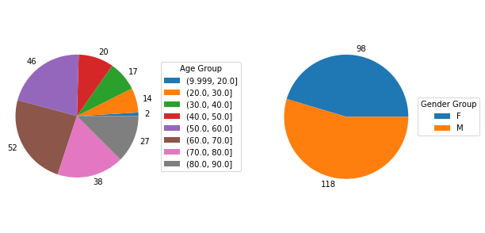

```python
# Add a new column in the data frame for age group
df['age_group'] = pd.cut(df.Age, bins=[g for g in range(10, 91, 10)], include_lowest=True)

pyplot.subplot(1, 2, 1)
# Create first chart here.
pyplot.pie(df.groupby(['age_group']).size(),labels= df.groupby(['age_group']).size())
pyplot.legend( title="Age Group",
              labels= df.groupby(['age_group']).size().index.tolist(),
              loc="center left",
              bbox_to_anchor=(1.1, 0, 0.5, 1))
pyplot.axis('equal')
pyplot.tight_layout()

pyplot.subplot(1, 2, 2)
# Create second chart here.
pyplot.pie(df.groupby(['Gender']).size(),labels= df.groupby(['Gender']).size())
pyplot.legend( title="Gender Group",
              labels= df.groupby(['Gender']).size().index.tolist(),
              loc="center left",
              bbox_to_anchor=(1, 0, 0.5, 1))
pyplot.axis('equal')
pyplot.tight_layout()


pyplot.tight_layout(pad=0.4, w_pad=0.5, h_pad=1.0)
pyplot.subplots_adjust(left=None, bottom=None, right=1.2, top=None, wspace=1, hspace=None)

pyplot.show() #show all figures
```

## Pupil Data

Pupil data measures different kinds of metrics including patients' pupil sizes, constriction velocity, dilation velocity, latency and NPi, etc. In this section, we look at data from both left and right eye of a patient and determine their linear relationship, which helps our data processing analysis in future sections. In the scatterplots below, by color coding each patient's diagnosis, we can understand its distribution more clearly. It is interesting to see circles with darker colors occupying more space than ones with lighter colors. It could mean that there are more people suffering Intraparenchymal Hemorrhage than people with Infection or other disease. Although not directly shown, people with Intraparenchymal Hemorrhage or Subarachnoid Hemorrhage seem to have lower constriction velocity and dilation velocity.

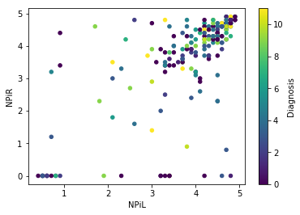

```python
ax1 = df.plot.scatter(x='NPiL',
...                       y='NPiR',
...                       c='Diagnosis',
...                       colormap='viridis', sharex=False)
ax1
```

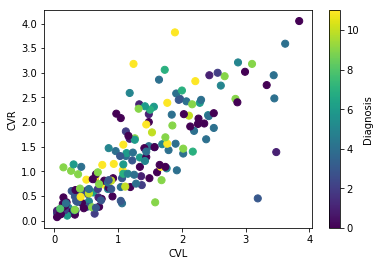

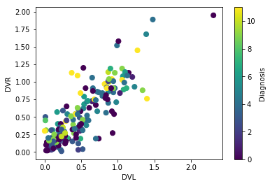

```python
x0 = ['CVL','DVL']
y0 = ['CVR','DVR']
for i in range(0,2):
    ax2 = df.plot.scatter(x=x0[i],
                           y=y0[i], s=50,
                           c='Diagnosis',
                           colormap='viridis', sharex=False)
    ax2
```

## Diagnosis & Treatment

```python
# Add a new column for number of treatments
df['numOfTreatment'] = df['EVD'] + df['Hyperosmolar.Therapy'] + df['Brain.Surgery']
```

[figure not shown]

```python
pyplot.subplot(2, 2, 1)
# Create first chart here.
pyplot.pie(df.groupby(['Diagnosis']).size(),labels= df.groupby(['Diagnosis']).size())
pyplot.legend( title="Diagnosis Code",
              labels= df.groupby(['Diagnosis']).size().index.tolist(),
              loc="center left",
              bbox_to_anchor=(1.1, 0, 0.5, 1))
pyplot.axis('equal')
pyplot.tight_layout()

pyplot.subplot(2, 2, 2)
# Create second chart here.
pyplot.pie(df.groupby(['numOfTreatment']).size(),labels= df.groupby(['numOfTreatment']).size())
pyplot.legend( title="Number of Treatments",
              labels= df.groupby(['numOfTreatment']).size().index.tolist(),
              loc="center left",
              bbox_to_anchor=(1, 0, 0.5, 1))
pyplot.axis('equal')
pyplot.tight_layout()


pyplot.tight_layout(pad=0.4, w_pad=0.5, h_pad=1.0)
pyplot.subplots_adjust(left=None, bottom=None, right=1.2, top=None, wspace=1, hspace=0.7)

pyplot.show() #show all figures
```

[figure not shown]

```python
# Create third chart here.
s=pd.to_numeric(df['numOfTreatment']).groupby(df['Diagnosis'])

pyplot.bar(s.mean().index, s.mean())
pyplot.ylabel('Averge Number of Treatments')
pyplot.xlabel('Diagnosis Code')
# pyplot.legend( title="Averge Number of Treatments",
#               labels= s.mean().values,
#               loc="center left",
#               bbox_to_anchor=(1, 0, 0.5, 1))
# pyplot.axis('equal')
pyplot.tight_layout()
```

## Surgery Data Analysis

This section allows us to explore the statistics of the surgeries. In the first bar chart, the number of patients undergoing a surgery and one that don't are compared. They are grouped based on their different NPi's. We can see that, non-surgery treatment is usually widely adopted, no matter what NPi a patient has. In the event of a patient with NPi higher than 4, they have a lower chance to having to go through a surgery. Of course, there are other factors involved in this decision.

In the next two charts, we further visualize how EVD and Hyperosmolar Therapy are used as intervention options other than surgery. The graphs show us that, for surgery patients, it's very likely that they are treated with a combination of EVD and Hyperosmolar Therapy. However, for non-surgery patients, especially those with higher NPi's, there is a big chance that they are treated with therapy only.

[figure not shown]

```python
# Build 2 new dataframes with surgery and non-surgery
df_1 = df[(df["Brain.Surgery"].isin([0]) )]
df_2 = df[(df["Brain.Surgery"].isin([1]) )]

bins = np.linspace(0,5,6)

# graph 1
pyplot.hist((df_1['NPiL'],df_2['NPiL']),bins,alpha=0.5,label=["Non-Surgery","Surgery", "Brain Surgery"],histtype='bar')
pyplot.title("Non-Surgery VS Surgery")

pyplot.tight_layout(pad=0.4, w_pad=0.5, h_pad=1.0)

pyplot.show()
```

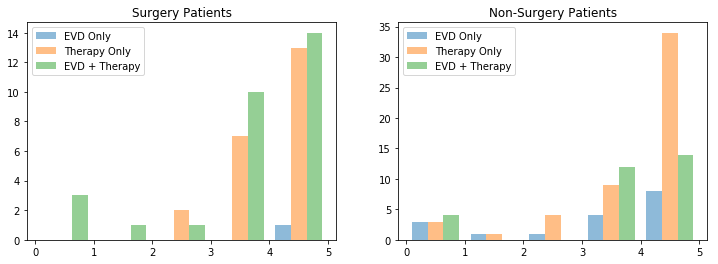

```python
# graph 2
df_3 = df_2[(df_2["EVD"].isin([1]) & df["Hyperosmolar.Therapy"].isin([0]) )]
df_4 = df_2[(df_2["EVD"].isin([0]) & df["Hyperosmolar.Therapy"].isin([1]) )]
df_5 = df_2[(df_2["EVD"].isin([1]) & df["Hyperosmolar.Therapy"].isin([1]) )]
pyplot.subplot(1, 2, 1)
pyplot.hist((df_3['NPiL'],df_4['NPiL'],df_5['NPiL']),bins,alpha=0.5,label=["EVD Only","Therapy Only", "EVD + Therapy"],histtype='bar')
pyplot.legend(loc="upper left")
pyplot.title("Surgery Patients")

# graph3
df_6 = df_1[(df_1["EVD"].isin([1]) & df["Hyperosmolar.Therapy"].isin([0]) )]
df_7 = df_1[(df_1["EVD"].isin([0]) & df["Hyperosmolar.Therapy"].isin([1]) )]
df_8 = df_1[(df_1["EVD"].isin([1]) & df["Hyperosmolar.Therapy"].isin([1]) )]
pyplot.subplot(1, 2, 2)
pyplot.hist((df_6['NPiL'],df_7['NPiL'],df_8['NPiL']),bins,alpha=0.5,label=["EVD Only","Therapy Only", "EVD + Therapy"],histtype='bar')
pyplot.legend(loc="upper left")
pyplot.title("Non-Surgery Patients")

pyplot.subplots_adjust(left=None, bottom=None, right=1.7, top=None, wspace=0.2, hspace=0.7)
pyplot.show()
```

The below code constructs a regression model to predict the adoption of a surgery in treatment, using the data from NPi, Pupil size and Latency. The result proves to be 69% accurate, which is acceptable.

```python
# Scale larger positive and values to between -1,1 depending on the largest
# Value in the data
min_max_scaler = preprocessing.MinMaxScaler(feature_range=(-1,1))
df = pd.read_csv("data2.csv", header=0).dropna()

# Clean up data
df.columns = ["NPiL","SizeL","LatL","NPiR","SizeR","LatR","Brain_Surgery_label"]

#x = df["label"].map(lambda x: float(x.rstrip(';')))

# Formats the input data into two arrays, one of independent variables
# and one of the dependant variable
X = df[["NPiL","SizeL","LatL","NPiR","SizeR","LatR"]]
X = np.array(X)
X = min_max_scaler.fit_transform(X)
Y = df["Brain_Surgery_label"]
Y = np.array(Y)

# Creating testing and training set into 20 and 80 percent
X_train,X_test,Y_train,Y_test = train_test_split(X,Y,test_size=0.20)

# Train scikit learn model
clf = LogisticRegression()
clf.fit(X_train,Y_train)
print ('Accuracy of the model: {}'.format(clf.score(X_test,Y_test)))
```

```
Accuracy of the model: 0.6903790087463557
```

## Data Process - Ending NPi

Another data frame is constructed here in order to compare the changes or patients' NPi value. By processing data for a second time, we consider the changes in patients' pupil measurement. This time, we look at the start NPi and the ending NPi of each patient to discover the trend in those changes and how it's related to other data.

```python
df2 = pd.DataFrame(columns=['ID','startNPi','endNPi','EVD','therapy','surgery'])
firstID = True
oldID = None
myRow = None

for index, row in data.iterrows():
    thisID = row['Study_ID']
    lastID = oldID

    lastRow = myRow
    thisRow = row

    if firstID:
        # Add the first row to the data frame
        start = row['NPiL']
        lastID = thisID
        firstID = False
    else:
        # When the ID is different and NPI is valid
        if thisID != lastID and row['NPiL']>0:
            end = lastRow['NPiL']
            if end>0:
                df2.loc[len(df2)] = [lastID, start, end,lastRow['EVD'],lastRow['Hyperosmolar.Therapy'],lastRow['Brain.Surgery']]
            start = row['NPiL']
            lastID = thisID
    myRow = row
    oldID = thisID

end = myRow['NPiL']
df2.loc[len(df2)] = [oldID, start, end,lastRow['EVD'],lastRow['Hyperosmolar.Therapy'],lastRow['Brain.Surgery']]

# Convert ID column to int type
df2 = df2.astype({"ID": int,"therapy": int,"EVD": int,"surgery": int})

# Show first 5 rows of processed data frame
df2.head()
```

|  | ID | startNPi | endNPi | EVD | therapy | surgery |
| --- | --- | --- | --- | --- | --- | --- |
| 0 | 164 | 3.9 | 4.8 | 0 | 0 | 0 |
| 1 | 165 | 4.8 | 4.9 | 0 | 0 | 1 |
| 2 | 166 | 3.9 | 4.3 | 0 | 0 | 0 |
| 3 | 167 | 4.5 | 4.8 | 0 | 0 | 0 |
| 4 | 170 | 4.8 | 4.8 | 0 | 0 | 0 |

## NPi Changes

In this last section, we first divide patient data into groups based on what intervention they are given. The graphs are color coded, where red means their NPi drops and green means it increases. Each vertical line represents one patient and the length of the line is how much their NPi has changed.

By comparing these three graphs, we can tell the surgery usually causes more drastic changes, whereas on the other two charts, dots appear more than long lines. If we consider removing extreme cases, therapy seems to affect NPi value in a more positive way than the others.

```python
# Sub group patient info into 3 sub dataframes
df_evd = df2[(df2["EVD"].isin([1]))]
df_therapy = df2[(df2["therapy"].isin([1]) )]
df_surgery = df2[(df2["surgery"].isin([1]))]
```

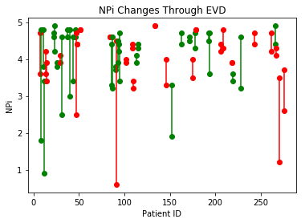

```python
for index, row in df_evd.iterrows():
    color = 'g' if (row['startNPi'] < row['endNPi']).all() else 'r'
    pyplot.plot([row['ID'],row['ID']],[row['startNPi'],row['endNPi']],c=color,linestyle='-', marker='o')

# Add title and axis names
pyplot.title('NPi Changes Through EVD')
pyplot.xlabel('Patient ID')
pyplot.ylabel('NPi')

pyplot.show()
```

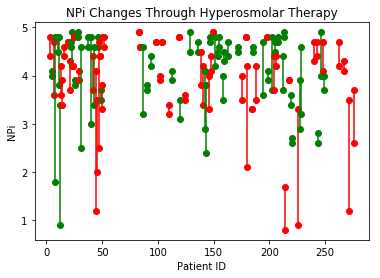

```python
for index, row in df_therapy.iterrows():
    color = 'g' if (row['startNPi'] < row['endNPi']).all() else 'r'
    pyplot.plot([row['ID'],row['ID']],[row['startNPi'],row['endNPi']],c=color,linestyle='-', marker='o')

# Add title and axis names
pyplot.title('NPi Changes Through Hyperosmolar Therapy')
pyplot.xlabel('Patient ID')
pyplot.ylabel('NPi')

pyplot.show()
```

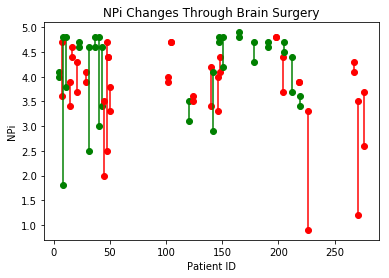

```python
for index, row in df_surgery.iterrows():
    color = 'g' if (row['startNPi'] < row['endNPi']).all() else 'r'
    pyplot.plot([row['ID'],row['ID']],[row['startNPi'],row['endNPi']],c=color,linestyle='-', marker='o')

# Add title and axis names
pyplot.title('NPi Changes Through Brain Surgery')
pyplot.xlabel('Patient ID')
pyplot.ylabel('NPi')

pyplot.show()
```

## Reference

- Kevin Amipare. A better visualisation of Pie charts by MatPlotLib. Retrieved from https://medium.com/@kvnamipara/a-better-visualisation-of-pie-charts-by-matplotlib-935b7667d77f
- Matplotlib Documentation. Retrieved from https://matplotlib.org/api/_as_gen/matplotlib.pyplot.html
- Ong C, Hutch M, Barra M, Kim A, Zafar S, Smirnakis S. Effects of osmotic therapy on pupil reactivity: Quantification using pupillometry in critically ill neurologic patients. Neurocrit Care. 2018
- Pandas DataFrame Documentation. Retrieved from https://pandas.pydata.org/pandas-docs/stable/reference/frame.html
- Pupillary response. Wikipedia. Retrived from https://en.wikipedia.org/wiki/Pupillary_response
- Stack Overflow. From stackoverflow.com